# Final Project

Multilevel Modeling

Joaquin Menendez (jm622)

December 4, 2018

# Influence of Semantic Similarity and Stimulus Onset Asynchrony on Semantic Subliminal Processing

##### *Studies employing a masked priming paradigm have observed that subliminal stimuli could be processed on a semantic level. Semantic categorization of a consciously perceived stimulus could be facilitated by the presentation of a former stimulus that was not consciously perceived (subliminal). This facilitation is usually measured as the reaction time employed to respond to a task. When this facilitation occurs between congruent pairs of stimuli (from the same category) and does not occur between incongruent pairs (from different categories) is called congruency priming effect. Two principal factors modulate the subliminal priming effect, the semantic similarity between stimuli and the SOA. Semantic similarity refers to the similarity in meaning or overlap of features between two words. The greater the similarity, the bigger the facilitation. Another factor that modulates priming effect is the interval between the onset of the first stimulus and the onset of the second stimulus of the par (SOA: stimulus onset asynchrony), showing that the bigger the SOA, the lower priming effect. Despite the fact that these two phenomena have been extensively studied, it has not been studied the influence of semantic strength has not been studied together with SOA duration. The goal of this study is to observe if semantic relatedness (strongly and weakly related pairs) could modulate congruency priming effect duration. To evaluate this, both semantic relatedness (strong and weak) and SOA were manipulated in a subliminal semantic priming task.*<

Exploratory analysis of the selected variable

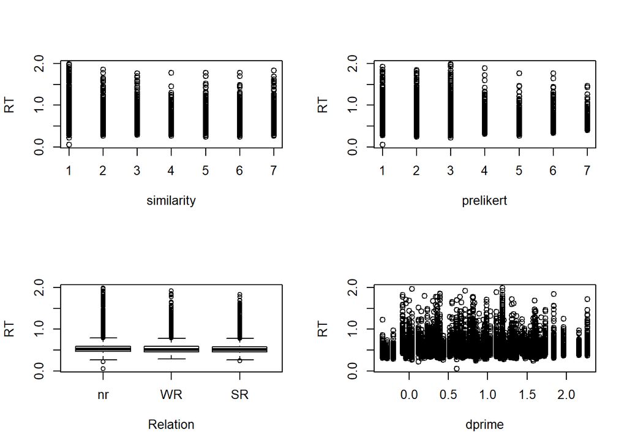

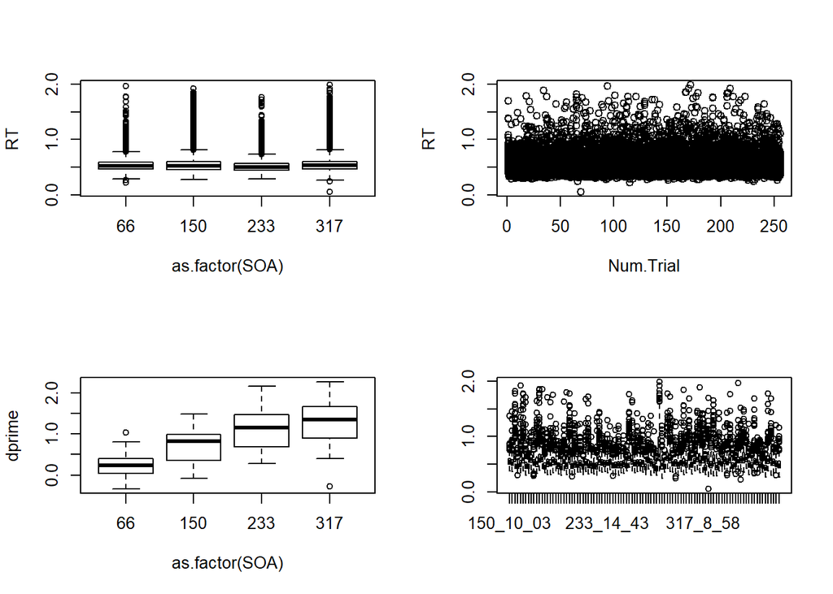

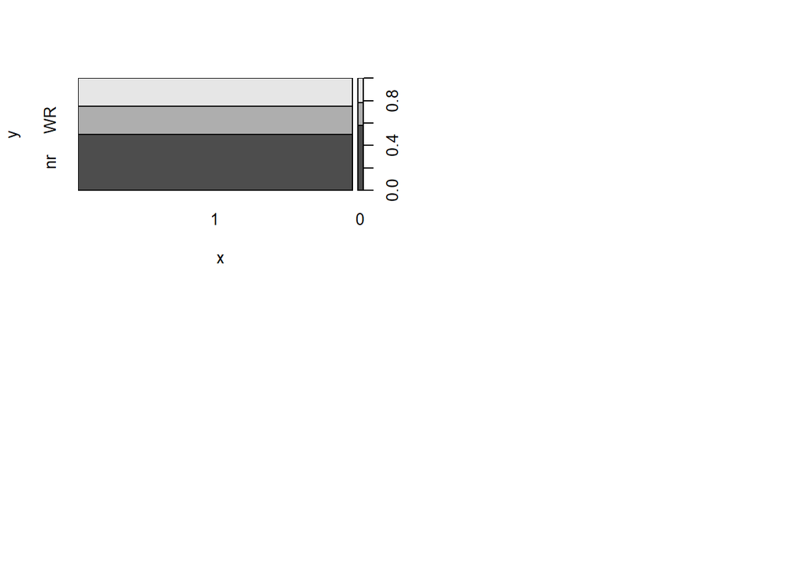

```r
par(mfrow=c(2,2))
plot(RT~similarity+prelikert+Relation+dprime+as.factor(SOA)+Num.Trial,data = dffinal)
plot(dprime~as.factor(SOA), data = dffinal)
#We definetively have an effect of SOA on dprime. We dont observe this effect of dprime nor SOA over RT.
# No clear effect of relation on RT (maybe this is only observable for the correct answers)

plot(as.factor(dffinal$ID),dffinal$RT)
plot(dffinal$Answer,dffinal$Relation)
#There is a slightly difference of correct answers depending on the relation. Subjects have more mistakes when relation is not related.
# This could be model with a logistic regression in a future approach, for this analysis we are only going to use correct responses.
```

Correlation Plot

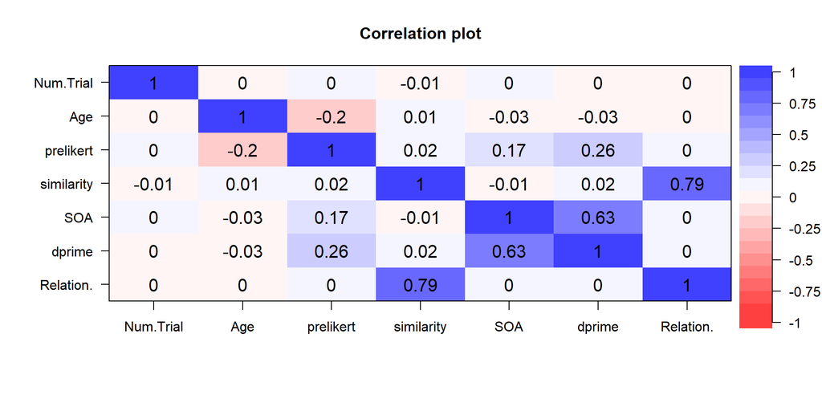

```r
cor.plot(dffinal[c(1,11,17,19,20,27,30)],n = 20, n.legend = 8, numbers = T,scale = F)
#corrplot(cor(dffinal[c(3,1,11,17,19,20,27,28,30)]),method = 'shade',title = 'Correlatio plot')
```

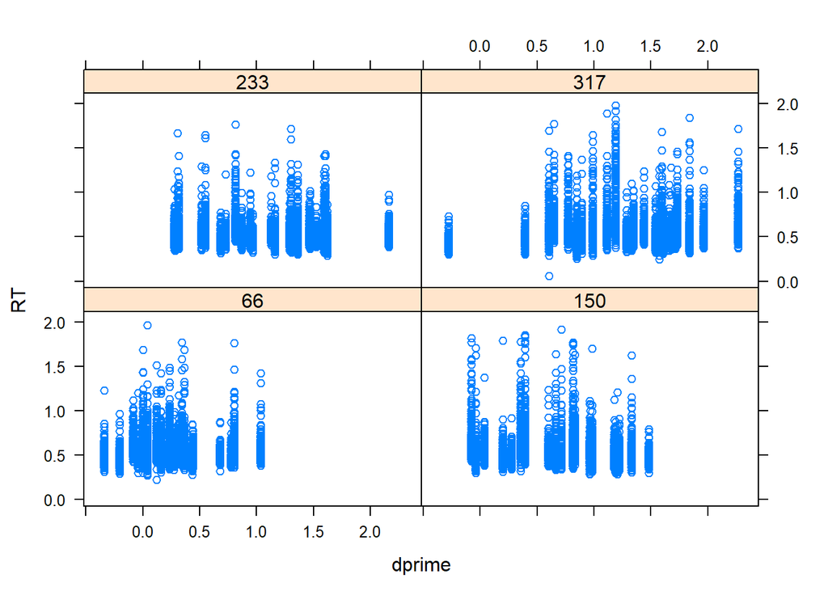

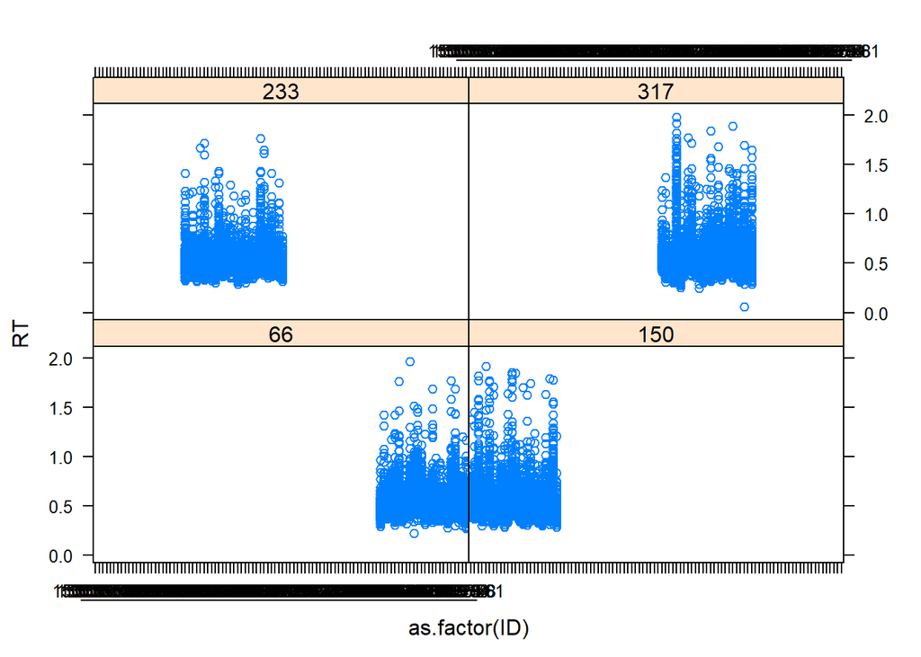

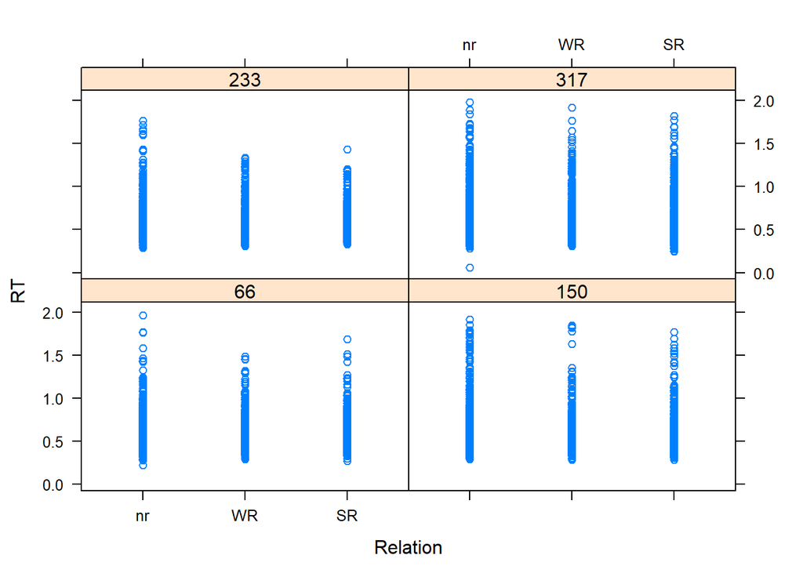

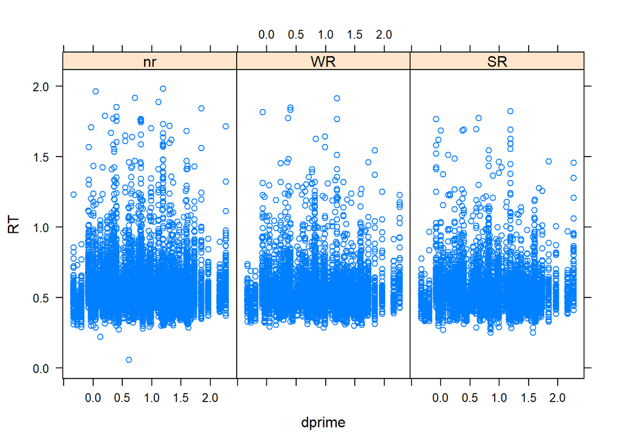

```r
par(mfrow=c(2,2))
xyplot(RT ~ dprime |as.factor(SOA) , data = dffinal)
xyplot(RT~as.factor(ID) | as.factor(SOA), data = dffinal)
xyplot(RT ~ Relation |as.factor(SOA) , data = dffinal)
xyplot(RT ~ dprime | Relation , data = dffinal) #It seems to be a sligthly reduction of time in the RT given the dprime value for each level of relation but honestly it is not really clear.
```

```r
# mean centering cuantitative trials  --- num.trial, similarity, dprime, prelikert
dffinal$c.Num.Trial = dffinal$Num.Trial - mean(dffinal$Num.Trial)
dffinal$c.similarity = dffinal$similarity - mean(dffinal$similarity)
dffinal$c.dprime = dffinal$dprime - mean(dffinal$dprime)
dffinal$c.prelikert = dffinal$prelikert - mean(dffinal$prelikert)
```

# Trying to fit a clasical linear regression

# Multilevel Model 1 - Different intercept

$Y_{ij} = \alpha_{j[i]} + \beta1_i * \beta2_{j[i]} + \epsilon_i$

```r
#Simplest herarchycal model
# != intercept by subject, same slope
df_no_error = dffinal[dffinal$Answer == 1,]
df_no_error$SOA = factor(df_no_error$SOA, levels = c( '66','150','233','317'))
df_no_error$Relation = factor(df_no_error$Relation, levels = c('nr', 'WR', 'SR'))
df_no_error$ID = as.factor(df_no_error$ID)

H_simple = lmer(log.RT ~ Relation * as.factor(SOA)  + (1|ID), data = df_no_error)
summary(H_simple)
```

```
## Linear mixed model fit by REML ['lmerMod']
## Formula: log.RT ~ Relation * as.factor(SOA) + (1 | ID)
##    Data: df_no_error
##
## REML criterion at convergence: -9799.5
##
## Scaled residuals:
##     Min      1Q  Median      3Q     Max
## -3.7823 -0.6067 -0.1026  0.4584  6.5436
##
## Random effects:
##  Groups   Name        Variance Std.Dev.
##  ID       (Intercept) 0.01156  0.1075
##  Residual             0.03881  0.1970
## Number of obs: 25073, groups:  ID, 100
##
## Fixed effects:
##                               Estimate Std. Error t value
## (Intercept)                  -0.614797   0.022236 -27.649
## RelationWR                   -0.019273   0.006193  -3.112
## RelationSR                   -0.017657   0.006200  -2.848
## as.factor(SOA)150             0.012400   0.031450   0.394
## as.factor(SOA)233            -0.038317   0.030562  -1.254
## as.factor(SOA)317             0.022771   0.031130   0.731
## RelationWR:as.factor(SOA)150 -0.002686   0.008783  -0.306
## RelationSR:as.factor(SOA)150 -0.013033   0.008794  -1.482
## RelationWR:as.factor(SOA)233  0.007034   0.008542   0.823
## RelationSR:as.factor(SOA)233  0.006620   0.008540   0.775
## RelationWR:as.factor(SOA)317  0.005813   0.008677   0.670
## RelationSR:as.factor(SOA)317 -0.008463   0.008686  -0.974
##
## Correlation of Fixed Effects:
##             (Intr) RltnWR RltnSR a.(SOA)1 a.(SOA)2 a.(SOA)3 RWR:.(SOA)1
## RelationWR  -0.093
## RelationSR  -0.093  0.335
## as.(SOA)150 -0.707  0.066  0.066
## as.(SOA)233 -0.728  0.068  0.068  0.514
## as.(SOA)317 -0.714  0.067  0.067  0.505    0.520
## RWR:.(SOA)1  0.066 -0.705 -0.236 -0.094   -0.048   -0.047
## RSR:.(SOA)1  0.066 -0.236 -0.705 -0.094   -0.048   -0.047    0.336
## RWR:.(SOA)2  0.068 -0.725 -0.243 -0.048   -0.093   -0.048    0.511
## RSR:.(SOA)2  0.068 -0.243 -0.726 -0.048   -0.093   -0.048    0.172
## RWR:.(SOA)3  0.067 -0.714 -0.239 -0.047   -0.049   -0.093    0.503
## RSR:.(SOA)3  0.067 -0.239 -0.714 -0.047   -0.048   -0.093    0.169
##             RSR:.(SOA)1 RWR:.(SOA)2 RSR:.(SOA)2 RWR:.(SOA)3
## RelationWR
## RelationSR
## as.(SOA)150
## as.(SOA)233
## as.(SOA)317
## RWR:.(SOA)1
## RSR:.(SOA)1
## RWR:.(SOA)2  0.171
## RSR:.(SOA)2  0.512       0.335
## RWR:.(SOA)3  0.169       0.518       0.174
## RSR:.(SOA)3  0.503       0.173       0.518       0.334
```

# Multilevel Model 2 - Different intercept (with Num.trial)

$Y_{ij} = \alpha_{j[i]} + \beta1_i * \beta2_{j[i]} + \beta_i+ \epsilon_i$

```r
H_difint = lmer(log.RT ~ Relation * as.factor(SOA) + c.Num.Trial + (1|ID), data = df_no_error) #try a simple without num
#look at the intercepts (and the common slope) for each ID
    #coef(H_difint)
summary(H_difint)
```

```
## Linear mixed model fit by REML ['lmerMod']
## Formula: log.RT ~ Relation * as.factor(SOA) + c.Num.Trial + (1 | ID)
##    Data: df_no_error
##
## REML criterion at convergence: -9797.2
##
## Scaled residuals:
##     Min      1Q  Median      3Q     Max
## -3.7846 -0.6084 -0.1031  0.4580  6.5556
##
## Random effects:
##  Groups   Name        Variance Std.Dev.
##  ID       (Intercept) 0.01155  0.1075
##  Residual             0.03878  0.1969
## Number of obs: 25073, groups:  ID, 100
##
## Fixed effects:
##                                Estimate Std. Error t value
## (Intercept)                  -6.148e-01  2.223e-02 -27.654
## RelationWR                   -1.923e-02  6.191e-03  -3.107
## RelationSR                   -1.762e-02  6.198e-03  -2.844
## as.factor(SOA)150             1.245e-02  3.144e-02   0.396
## as.factor(SOA)233            -3.833e-02  3.056e-02  -1.254
## as.factor(SOA)317             2.276e-02  3.113e-02   0.731
## c.Num.Trial                   7.122e-05  1.686e-05   4.225
## RelationWR:as.factor(SOA)150 -2.753e-03  8.780e-03  -0.314
## RelationSR:as.factor(SOA)150 -1.299e-02  8.791e-03  -1.478
## RelationWR:as.factor(SOA)233  6.957e-03  8.539e-03   0.815
## RelationSR:as.factor(SOA)233  6.604e-03  8.537e-03   0.774
## RelationWR:as.factor(SOA)317  5.830e-03  8.674e-03   0.672
## RelationSR:as.factor(SOA)317 -8.494e-03  8.683e-03  -0.978
```

```
##
## Correlation matrix not shown by default, as p = 13 > 12.
## Use print(x, correlation=TRUE)  or
##     vcov(x)        if you need it
```

```r
#We would like to compare models
anova(H_simple,H_difint)
```

```
## refitting model(s) with ML (instead of REML)
```

```
## Data: df_no_error
## Models:
## H_simple: log.RT ~ Relation * as.factor(SOA) + (1 | ID)
## H_difint: log.RT ~ Relation * as.factor(SOA) + c.Num.Trial + (1 | ID)
##          Df     AIC     BIC logLik deviance  Chisq Chi Df Pr(>Chisq)
## H_simple 14 -9862.3 -9748.5 4945.1  -9890.3
## H_difint 15 -9878.1 -9756.2 4954.1  -9908.1 17.855      1  2.384e-05 ***
## ---
## Signif. codes:  0 '***' 0.001 '**' 0.01 '*' 0.05 '.' 0.1 ' ' 1
```

The F-nested Test present evidence to reject the null hypothesis that both models are equal good to describe the data. The inclusion of the variable Num.Trial in model 2, allow us to better describe the data ($X^2$ = 17.855, p < .001). It seems that subjects experience fatigue after the large amount of trials, this data is congruent with the scientific knowledge. The inclusion of Num. of trials seems to improbe the model, so we are going to incorporate this variable.

# Multilevel Model 2 - Different intercept (with Similarity instead of Relation)

```r
#Model with similarity instead of relation
H_difint2 = lmer(log.RT ~ c.similarity * as.factor(SOA) + c.Num.Trial + (1|ID), data = df_no_error)
summary(H_difint2)
```

```
## Linear mixed model fit by REML ['lmerMod']
## Formula: log.RT ~ c.similarity * as.factor(SOA) + c.Num.Trial + (1 | ID)
##    Data: df_no_error
##
## REML criterion at convergence: -9797.2
##
## Scaled residuals:
##     Min      1Q  Median      3Q     Max
## -3.8011 -0.6084 -0.1035  0.4595  6.5826
##
## Random effects:
##  Groups   Name        Variance Std.Dev.
##  ID       (Intercept) 0.01156  0.1075
##  Residual             0.03881  0.1970
## Number of obs: 25073, groups:  ID, 100
##
## Fixed effects:
##                                  Estimate Std. Error t value
## (Intercept)                    -6.238e-01  2.210e-02 -28.232
## c.similarity                   -3.831e-03  1.230e-03  -3.116
## as.factor(SOA)150               8.288e-03  3.125e-02   0.265
## as.factor(SOA)233              -3.553e-02  3.037e-02  -1.170
## as.factor(SOA)317               2.206e-02  3.093e-02   0.713
## c.Num.Trial                     7.106e-05  1.686e-05   4.214
## c.similarity:as.factor(SOA)150 -9.026e-04  1.734e-03  -0.521
## c.similarity:as.factor(SOA)233  3.235e-04  1.704e-03   0.190
## c.similarity:as.factor(SOA)317 -2.377e-04  1.705e-03  -0.139
##
## Correlation of Fixed Effects:
##             (Intr) c.smlr a.(SOA)1 a.(SOA)2 a.(SOA)3 c.Nm.T c.:.(SOA)1
## c.similarty -0.004
## as.(SOA)150 -0.707  0.003
## as.(SOA)233 -0.728  0.003  0.514
## as.(SOA)317 -0.714  0.003  0.505    0.520
## c.Num.Trial  0.000  0.000  0.000    0.000    0.000
## c.:.(SOA)15  0.003 -0.709 -0.002   -0.002   -0.002    0.003
## c.:.(SOA)23  0.003 -0.722 -0.002    0.001   -0.002    0.001  0.512
## c.:.(SOA)31  0.003 -0.721 -0.002   -0.002   -0.003    0.002  0.512
##             c.:.(SOA)2
## c.similarty
## as.(SOA)150
## as.(SOA)233
## as.(SOA)317
## c.Num.Trial
## c.:.(SOA)15
## c.:.(SOA)23
## c.:.(SOA)31  0.520
```

```r
#fixef(H_difint2)

anova(H_difint,H_difint2)
```

```
## refitting model(s) with ML (instead of REML)
```

```
## Data: df_no_error
## Models:
## H_difint2: log.RT ~ c.similarity * as.factor(SOA) + c.Num.Trial + (1 | ID)
## H_difint: log.RT ~ Relation * as.factor(SOA) + c.Num.Trial + (1 | ID)
##           Df     AIC     BIC logLik deviance  Chisq Chi Df Pr(>Chisq)
## H_difint2 11 -9865.1 -9775.7 4943.6  -9887.1
## H_difint  15 -9878.1 -9756.2 4954.1  -9908.1 21.002      4  0.0003163 ***
## ---
## Signif. codes:  0 '***' 0.001 '**' 0.01 '*' 0.05 '.' 0.1 ' ' 1
```

The fact that Relation is better could be due to several reasons. Having time to think (as in the case of the Similarity task compared to the experimental task) about a relation between two stimulus could bias the answers. Subjects could response using complex reasoning. It’s possible that this reasoning not be present during a subliminal processing. In this sense, we could agree with the ‘Wisdom of the crows’. In other words, multitudes known better us that ourselves.

Another possibility is that given that each subject reported a value of simmilarity, in other words the value is not fixed for all subjects, and the fact that ID as Random group includes the variability of the subject this effect was already covered by the random group.

# Model 3 - Different slope and different intercept

```r
#herarchycal model  with != intercept by subject, different slope by treatment.
# != intercept by subject, same slope
df_no_error = dffinal[dffinal$Answer == 1,]
df_no_error$SOA = as.factor(df_no_error$SOA)

H_difint_difslope = lmer(log.RT ~ Relation * SOA + c.Num.Trial + (1+ SOA |ID), data = df_no_error)
#look at the intercepts (and the common slope) for each ID
#coef(H_difint_difslope)

#these equal the fixed effects plus the random effect
summary(H_difint_difslope)
```

```
## Linear mixed model fit by REML ['lmerMod']
## Formula: log.RT ~ Relation * SOA + c.Num.Trial + (1 + SOA | ID)
##    Data: df_no_error
##
## REML criterion at convergence: -9804.7
##
## Scaled residuals:
##     Min      1Q  Median      3Q     Max
## -3.7873 -0.6085 -0.1033  0.4582  6.5561
##
## Random effects:
##  Groups   Name        Variance Std.Dev. Corr
##  ID       (Intercept) 0.010439 0.10217
##           SOA150      0.003279 0.05726  -0.09
##           SOA233      0.020383 0.14277  -0.86  0.15
##           SOA317      0.031897 0.17860  -0.67  0.21  0.72
##  Residual             0.038783 0.19693
## Number of obs: 25073, groups:  ID, 100
##
## Fixed effects:
##                     Estimate Std. Error t value
## (Intercept)       -6.148e-01  2.116e-02 -29.054
## RelationWR        -1.923e-02  6.191e-03  -3.107
## RelationSR        -1.762e-02  6.198e-03  -2.844
## SOA150             1.244e-02  3.141e-02   0.396
## SOA233            -3.832e-02  2.600e-02  -1.474
## SOA317             2.276e-02  3.423e-02   0.665
## c.Num.Trial        7.122e-05  1.686e-05   4.225
## RelationWR:SOA150 -2.752e-03  8.780e-03  -0.313
## RelationSR:SOA150 -1.299e-02  8.791e-03  -1.478
## RelationWR:SOA233  6.956e-03  8.539e-03   0.815
## RelationSR:SOA233  6.605e-03  8.537e-03   0.774
## RelationWR:SOA317  5.834e-03  8.674e-03   0.673
## RelationSR:SOA317 -8.494e-03  8.683e-03  -0.978
```

```
##
## Correlation matrix not shown by default, as p = 13 > 12.
## Use print(x, correlation=TRUE)  or
##     vcov(x)        if you need it
```

```r
#fixef(H_difint_difslope)
#ranef(H_difint_difslope)
```

# Model 3 - Different slope and different intercept( with Similarity instead of Relation)

```r
#Same model but with similarity instead of relation
H_difint_difslope2 = lmer(log.RT ~ c.similarity * SOA + c.Num.Trial + (1+ SOA |ID), data = df_no_error)
summary(H_difint_difslope2)
```

```
## Linear mixed model fit by REML ['lmerMod']
## Formula: log.RT ~ c.similarity * SOA + c.Num.Trial + (1 + SOA | ID)
##    Data: df_no_error
##
## REML criterion at convergence: -9804.7
##
## Scaled residuals:
##     Min      1Q  Median      3Q     Max
## -3.8036 -0.6080 -0.1032  0.4598  6.5832
##
## Random effects:
##  Groups   Name        Variance Std.Dev. Corr
##  ID       (Intercept) 0.010322 0.10160
##           SOA150      0.006038 0.07770  -0.24
##           SOA233      0.005151 0.07177  -0.66  0.64
##           SOA317      0.013149 0.11467  -0.24  0.65  0.49
##  Residual             0.038809 0.19700
## Number of obs: 25073, groups:  ID, 100
##
## Fixed effects:
##                       Estimate Std. Error t value
## (Intercept)         -6.238e-01  2.089e-02 -29.857
## c.similarity        -3.837e-03  1.230e-03  -3.120
## SOA150               8.285e-03  3.114e-02   0.266
## SOA233              -3.552e-02  2.567e-02  -1.384
## SOA317               2.206e-02  3.405e-02   0.648
## c.Num.Trial          7.106e-05  1.686e-05   4.214
## c.similarity:SOA150 -8.980e-04  1.734e-03  -0.518
## c.similarity:SOA233  3.285e-04  1.704e-03   0.193
## c.similarity:SOA317 -2.487e-04  1.705e-03  -0.146
##
## Correlation of Fixed Effects:
##             (Intr) c.smlr SOA150 SOA233 SOA317 c.Nm.T c.:SOA1 c.:SOA2
## c.similarty -0.004
## SOA150      -0.671  0.003
## SOA233      -0.814  0.003  0.546
## SOA317      -0.614  0.002  0.412  0.499
## c.Num.Trial  0.000  0.000  0.000  0.000  0.000
## c.sm:SOA150  0.003 -0.709 -0.002 -0.002 -0.002  0.003
## c.sm:SOA233  0.003 -0.722 -0.002  0.001 -0.002  0.001  0.512
## c.sm:SOA317  0.003 -0.721 -0.002 -0.002 -0.003  0.002  0.511   0.520
```

# Comparing models

```r
#anova(H_difint_difslope, H_difint_difslope2)
anova(H_difint, H_difint_difslope) #we would chose the first model given the simplicity
```

```
## refitting model(s) with ML (instead of REML)
```

```
## Data: df_no_error
## Models:
## H_difint: log.RT ~ Relation * as.factor(SOA) + c.Num.Trial + (1 | ID)
## H_difint_difslope: log.RT ~ Relation * SOA + c.Num.Trial + (1 + SOA | ID)
##                   Df     AIC     BIC logLik deviance  Chisq Chi Df
## H_difint          15 -9878.1 -9756.2 4954.1  -9908.1
## H_difint_difslope 24 -9867.8 -9672.7 4957.9  -9915.8 7.6923      9
##                   Pr(>Chisq)
## H_difint
## H_difint_difslope     0.5654
```

The F-nestd Test do not present statistical evidence of a difference between model 2 and 3 ($X^2$ = 7.69, p = 0.56). We would chose the first model given the simplicity, and because honestly It is difficult to understand what the other model is doing.

# Residuals plots Model 2

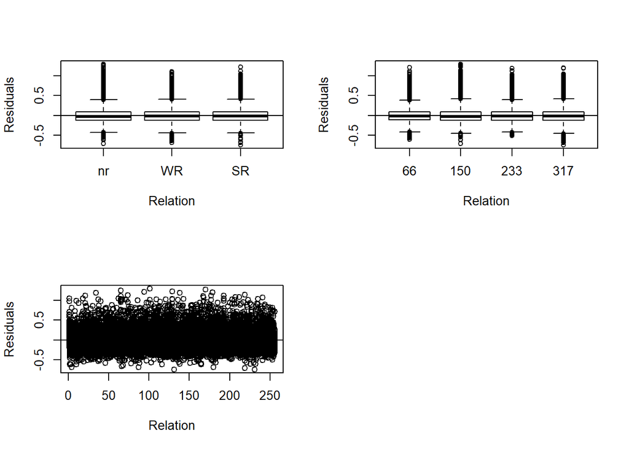

```r
#graphing some things
#plot residuals versus predictors
par(mfrow=c(2,2))

plot(y = residuals(H_difint), x = df_no_error$Relation, xlab= "Relation", ylab = "Residuals")
abline(0,0)
plot(y = residuals(H_difint), x = df_no_error$SOA, xlab= "Relation", ylab = "Residuals")
abline(0,0)
plot(y = residuals(H_difint), x = df_no_error$Num.Trial, xlab= "Relation", ylab = "Residuals")
abline(0,0)
```

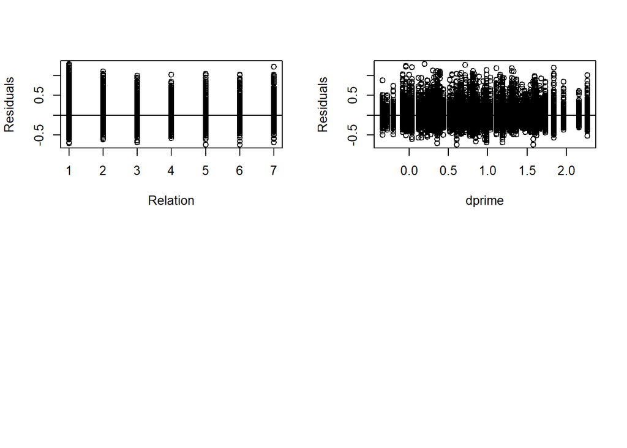

```r
#predictor not used
par(mfrow=c(2,2))
plot(y = residuals(H_difint), x = df_no_error$similarity, xlab= "Relation", ylab = "Residuals")
abline(0,0)
plot(y = residuals(H_difint), x = df_no_error$dprime, xlab= "dprime", ylab = "Residuals")
abline(0,0)
```

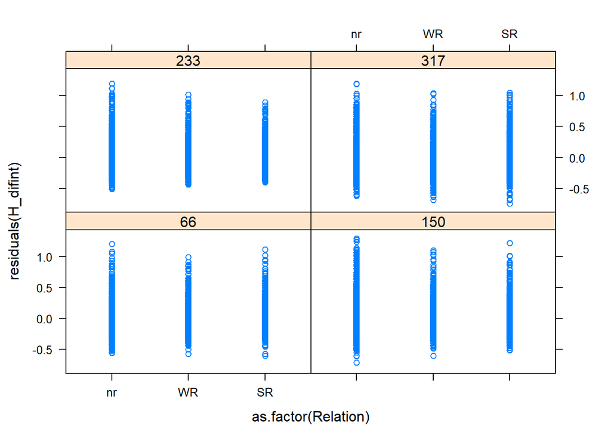

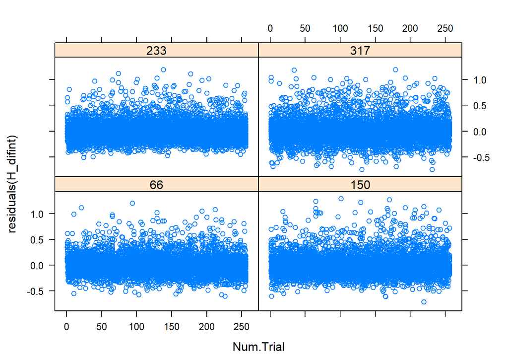

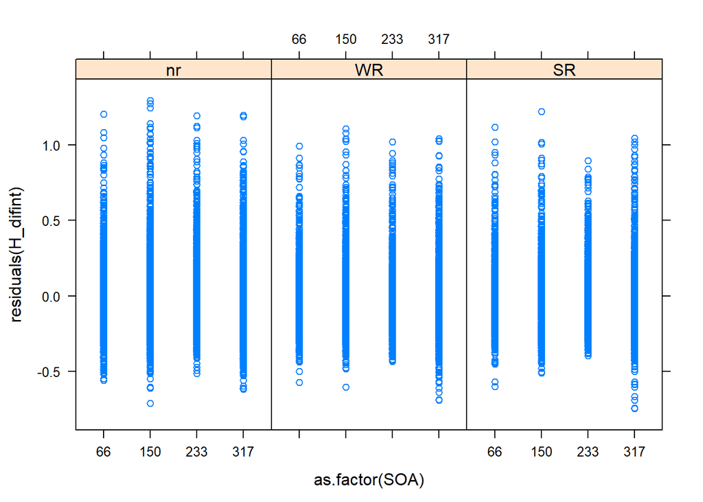

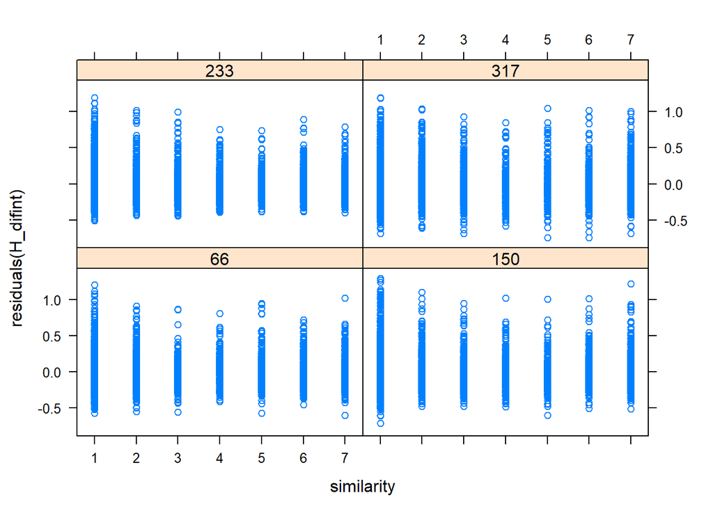

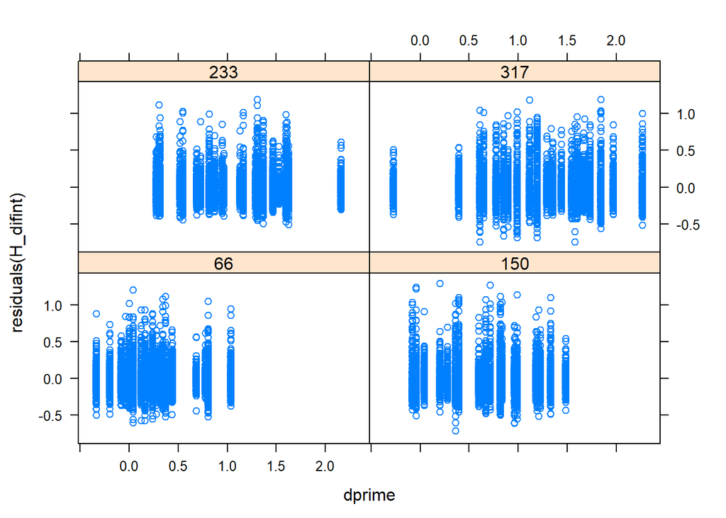

```r
par(mfrow=c(2,2))
#how about interactions?

xyplot(residuals(H_difint) ~ as.factor(Relation) | SOA, data = df_no_error)
xyplot(residuals(H_difint) ~ Num.Trial | as.factor(SOA), data = df_no_error)
xyplot(residuals(H_difint) ~ as.factor(SOA) | Relation, data = df_no_error)

#predictor not used
xyplot(residuals(H_difint) ~ similarity | SOA, data = df_no_error)
xyplot(residuals(H_difint) ~ dprime | SOA , data = df_no_error) #Thats a good reason to not use it.
```

```r
#Calculate coef interval for a baseline subject nr 66 -----
#install.packages('influence.ME')

coef = as.numeric(fixef(H_difint)[-1])
conditions = factor(c("WR","SR","SOA 150","SOA 233","SOA 317","Num.Trial","WR:SOA 150","SR:SOA 150","WR:SOA 233","SR:SOA 233","WR:SOA 317","SR:SOA 317"),levels = c("WR","SR","SOA 150","SOA 233","SOA 317","Num.Trial","WR:SOA 150","SR:SOA 150","WR:SOA 233","SR:SOA 233","WR:SOA 317","SR:SOA 317"))
colores = c(1,1,0,0,0,0,0,0,0,0,0,0)
coef_pos = coef + c(1.96)* (influence.ME::se.fixef(H_difint)[-1])
coef_neg = coef + c(-1.96)* (influence.ME::se.fixef(H_difint)[-1])
coefs = data.frame(cbind(coef,coef_pos,coef_neg)) #,conditions))
```

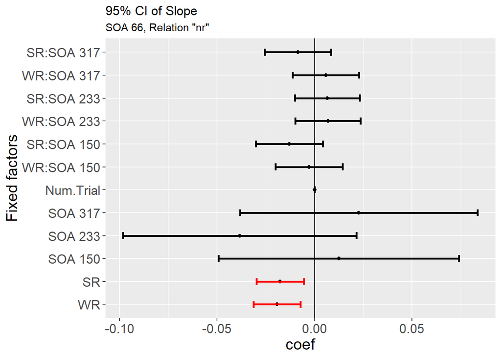

```r
# 95 confidence interval multilevel model H_difint, baseline subject nr 66  -----

ggplot(data= coefs, aes(x = conditions,y= coef, color = colores)) +  geom_point(stat="identity", color="black", position=position_dodge( width = .2)) + geom_errorbar(aes(ymin=coef_neg, ymax=coef_pos),size= 1, width=.3, position=position_dodge()) + geom_hline(yintercept = 0) +
  labs( x = 'Fixed factors', title ='95% CI of Slope', subtitle= 'SOA 66, Relation "nr"') +
  theme(axis.text.x = element_text(size=rel(1.5)),
        axis.text.y = element_text(size=rel(1.5)),
        axis.title.x = element_text(size = rel(1.4)),
        axis.title.y = element_text(size = rel(1.4)), legend.position = 'none' ) + coord_flip() + scale_color_gradient(low = "black", high = "red")
```

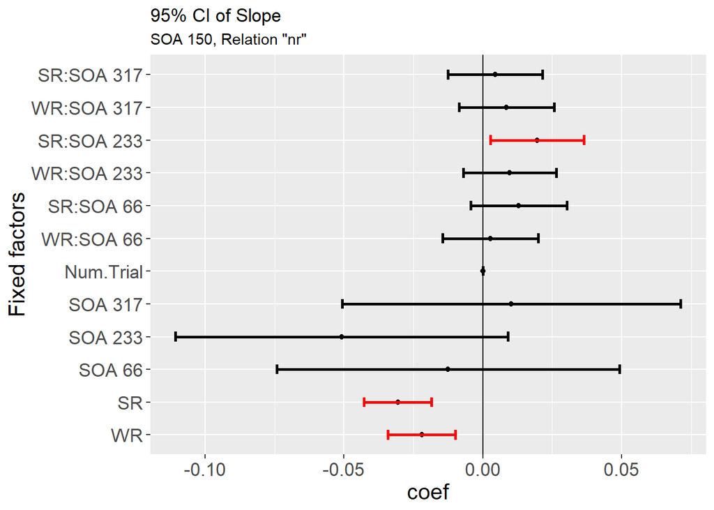

```r
#95 confidence interval multilevel model H_difint, baseline subject nr 150

df_no_error$SOA = factor(df_no_error$SOA, levels = c( '150','66','233','317'))
H_difint = lmer(log.RT ~ Relation * as.factor(SOA) + c.Num.Trial + (1|ID), data = df_no_error)
###############
coef = as.numeric(fixef(H_difint)[-1])
conditions = factor(c("WR","SR","SOA 66","SOA 233","SOA 317","Num.Trial","WR:SOA 66","SR:SOA 66","WR:SOA 233","SR:SOA 233","WR:SOA 317","SR:SOA 317"),levels = c("WR","SR","SOA 66","SOA 233","SOA 317","Num.Trial","WR:SOA 66","SR:SOA 66","WR:SOA 233","SR:SOA 233","WR:SOA 317","SR:SOA 317"))
colores = c(1,1,0,0,0,0,0,0,0,1,0,0)
coef_pos = coef + c(1.96)* (influence.ME::se.fixef(H_difint)[-1])
coef_neg = coef + c(-1.96)* (influence.ME::se.fixef(H_difint)[-1])
coefs = data.frame(cbind(coef,coef_pos,coef_neg)) #,conditions))
##############
ggplot(data= coefs, aes(x = conditions,y= coef, color = colores)) +  geom_point(stat="identity", color="black", position=position_dodge( width = .2)) + geom_errorbar(aes(ymin=coef_neg, ymax=coef_pos),size= 1, width=.3, position=position_dodge()) + geom_hline(yintercept = 0) +
  labs( x = 'Fixed factors', title ='95% CI of Slope', subtitle= 'SOA 150, Relation "nr"') +
  theme(axis.text.x = element_text(size=rel(1.5)),
        axis.text.y = element_text(size=rel(1.5)),
        axis.title.x = element_text(size = rel(1.4)),
        axis.title.y = element_text(size = rel(1.4)), legend.position = 'none' ) + coord_flip() + scale_color_gradient(low = "black", high = "red")
```

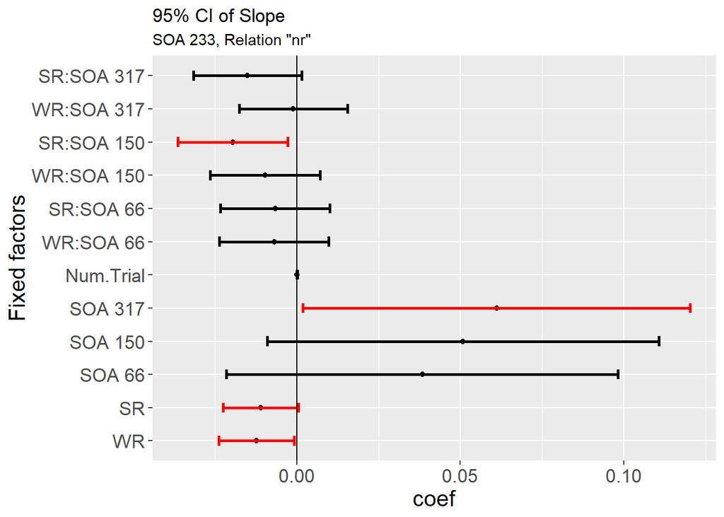

```r
#95 confidence interval multilevel model H_difint, baseline subject nr 233

df_no_error$SOA = factor(df_no_error$SOA, levels = c( '233','66','150','317'))
H_difint = lmer(log.RT ~ Relation * as.factor(SOA) + c.Num.Trial + (1|ID), data = df_no_error)
###############
coef = as.numeric(fixef(H_difint)[-1])
conditions = factor(c("WR","SR","SOA 66","SOA 150","SOA 317","Num.Trial","WR:SOA 66","SR:SOA 66","WR:SOA 150","SR:SOA 150","WR:SOA 317","SR:SOA 317"),levels = c("WR","SR","SOA 66","SOA 150","SOA 317","Num.Trial","WR:SOA 66","SR:SOA 66","WR:SOA 150","SR:SOA 150","WR:SOA 317","SR:SOA 317"))
colores = c(1,1,0,0,1,0,0,0,0,1,0,0)
coef_pos = coef + c(1.96)* (influence.ME::se.fixef(H_difint)[-1])
coef_neg = coef + c(-1.96)* (influence.ME::se.fixef(H_difint)[-1])
coefs = data.frame(cbind(coef,coef_pos,coef_neg)) #,conditions))
##############
ggplot(data= coefs, aes(x = conditions,y= coef, color = colores)) +  geom_point(stat="identity", color="black", position=position_dodge( width = .2)) + geom_errorbar(aes(ymin=coef_neg, ymax=coef_pos),size= 1, width=.3, position=position_dodge()) + geom_hline(yintercept = 0) +
  labs( x = 'Fixed factors', subtitle= 'SOA 233, Relation "nr"', title = '95% CI of Slope') +
  theme(axis.text.x = element_text(size=rel(1.5)),
        axis.text.y = element_text(size=rel(1.5)),
        axis.title.x = element_text(size = rel(1.4)),
        axis.title.y = element_text(size = rel(1.4)), legend.position = 'none' ) + coord_flip() + scale_color_gradient(low = "black", high = "red")
```